# NLP Final Project

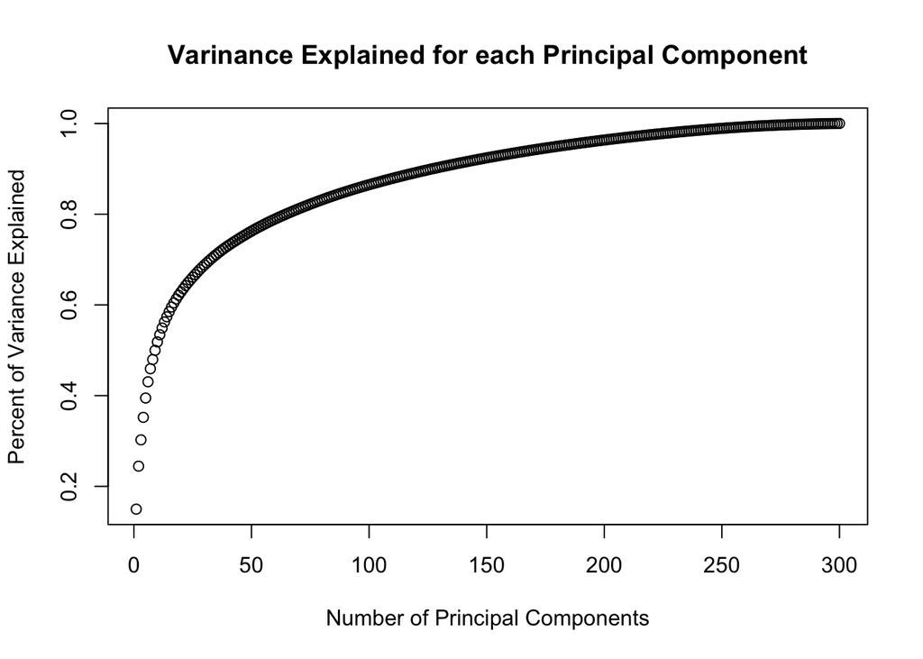

```r
plot(cumsum(prop), main = "Varinance Explained for each Principal Component", xlab="Number of Principal Components", ylab = "Percent of Variance Explained")
```

Create DF with Groups and Counts, counts in train test split

```r
z50=as.matrix(X_data) %*%as.matrix(PC[,1:50])
X_train50=as.matrix(z50[1:14134,])
y_train50=as.matrix(y_data[1:14134,])
X_test50=as.matrix(z50[14135:18846,])
y_test50=as.matrix(y_data[14135:18846,])
tc=c(799, 973, 985, 982, 963, 988, 975, 990, 996, 994, 999, 991, 984, 990, 987, 997, 910, 940, 775, 628)
testc=c(205, 245, 250, 243, 255, 240 ,249, 219, 246, 227, 287, 234, 247, 250, 240, 250 ,211 ,246, 209, 159 )
trainc=c(594, 728, 735, 739, 708, 748, 726, 771, 750, 767, 712, 757, 737, 740, 747, 747, 699, 694, 566, 469)
xr=c('alt.atheism',
 'comp.graphics',
 'comp.os.ms-windows.misc',
 'comp.sys.ibm.pc.hardware',
 'comp.sys.mac.hardware',
 'comp.windows.x',
 'misc.forsale',
 'rec.autos',
 'rec.motorcycles',
 'rec.sport.baseball',
 'rec.sport.hockey',
 'sci.crypt',
 'sci.electronics',
 'sci.med',
 'sci.space',
 'soc.religion.christian',
 'talk.politics.guns',
 'talk.politics.mideast',
 'talk.politics.misc',
 'talk.religion.misc')
xc=c("Article Topics","Total_Counts", "Train_Set_Counts", "Test_Set_Counts")
result= data.frame(xr,tc,trainc,testc)
colnames(result)=xc
result
```

| Article Topics | Total_Counts | Train_Set_Counts | Test_Set_Counts |
| --- | --- | --- | --- |
| alt.atheism | 799 | 594 | 205 |
| comp.graphics | 973 | 728 | 245 |
| comp.os.ms-windows.misc | 985 | 735 | 250 |
| comp.sys.ibm.pc.hardware | 982 | 739 | 243 |
| comp.sys.mac.hardware | 963 | 708 | 255 |
| comp.windows.x | 988 | 748 | 240 |
| misc.forsale | 975 | 726 | 249 |
| rec.autos | 990 | 771 | 219 |
| rec.motorcycles | 996 | 750 | 246 |
| rec.sport.baseball | 994 | 767 | 227 |

[output cut: 10 more lines]

$\textbf{K nearest Neighbors Classification}$ We look at K nearest Neighbors classification as our first approach to classify articles. We will use the numberic vectors for each vector to determine which group each data point belongs based on what the items that are nearest to it. This method is non-parametric and requires no assumptions about distributions. We determine the number of k values the algoritm will use to determine what group the point belongs to. We will compare the accuracy of using PCA and the full data set.

```r
library(class)
set.seed(1)
acuracy_rate=rep(0,50)
start_time=Sys.time()
for(i in 1:50){
  cls=knn(X_train50[,1:50], X_test50[,1:50], cl=y_train50[,1],k=i)
  a=table(cls, y_test50)
  acuracy_rate[i]=sum(diag(a))
}
end_time=Sys.time()
total_time=(end_time-start_time)
cat("\n k value with highest accuracy :",which.max(acuracy_rate))
```

```
##
##  k value with highest accuracy : 15
```

```r
cat("\n First 50 Principal Components Test set accuracy % :",acuracy_rate[which.max(acuracy_rate)]/4712)
```

```
##
##  First 50 Principal Components Test set accuracy % : 0.5717317
```

```r
cat("\n Average compute time for 50 runs with first 50 PC :",(total_time*60)/50)
```

```
##
##  Average compute time for 50 runs with first 50 PC : 2.758254
```

We found that for the first 50 principal components, a k value of 15 nearest neighbors gave us the best accuracy of 57% on the test set with an average compute time for each model run of 2.8 seconds.

```r
set.seed(1)
start_time=Sys.time()
cls=knn(X_train[,1:300], X_test, cl=y_train[,1],k=15)
end_time=Sys.time()
y1=as.matrix(y_test)
b=table(cls, y1)
cat("\n Full Test set accuracy % :",sum(diag(b))/4712)
```

```
##
##  Full Test set accuracy % : 0.5872241
```

```r
cat("\n Average compute time for full data set :",end_time-start_time)
```

```
##
##  Average compute time for full data set : 37.97868
```

```r
library(e1071)
svmdf50=as.data.frame(X_train50[,1:50])
svmdf50$Group=y_train50[,1]
svmdf50$Group=as.factor(svmdf50$Group)

start_time=Sys.time()
svmfit=svm(Group~., data=svmdf50, kernel="linear", cost=.01)


#Find predicted classes
pre_01 = predict(svmfit, X_test50[,1:50])
end_time=Sys.time()

y1=as.matrix(y_test)
pre=as.numeric(as.matrix(pre_01))
#table(pre, y1)
cat("\n Cost=.01,1st 50 PC's set accuracy % :",sum(diag(table(pre, y1)))/4712)
```

```
##
##  Cost=.01,1st 50 PC's set accuracy % : 0.6103565
```

```r
cat("\n Cost=.01,Compute time for 1st 50 PC's data set :",end_time-start_time)
```

```
##
##  Cost=.01,Compute time for 1st 50 PC's data set : 35.19969
```

```r
#Compute the confusion matrix
```

```r
library(e1071)
svmdf50=as.data.frame(X_train50[,1:50])
svmdf50$Group=y_train50[,1]
svmdf50$Group=as.factor(svmdf50$Group)

start_time=Sys.time()
svmfit=svm(Group~., data=svmdf50, kernel="polynomial", cost=.0001, gamma=1,degree=3)


#Find predicted classes
pre_01 = predict(svmfit, X_test50[,1:50])
end_time=Sys.time()

y1=as.matrix(y_test)
pre=as.numeric(as.matrix(pre_01))
#table(pre, y1)
cat("\n Cost=.0001,gamma=1,degree3,1st 50 PC's set accuracy % :",sum(diag(table(pre, y1)))/4712)
```

```
##
##  Cost=.0001,gamma=1,degree3,1st 50 PC's set accuracy % : 0.6449491
```

```r
cat("\n Cost=.0001,gamma=1,degree3,Compute time for 1st 50 PC's data set :",end_time-start_time)
```

```
##
##  Cost=.0001,gamma=1,degree3,Compute time for 1st 50 PC's data set : 37.85139
```

```r
#Compute the confusion matrix
```

```r
library(e1071)

svmdf=as.data.frame(X_train[,1:300])
svmdf$Group=y_train[,1]
svmdf$Group=as.factor(svmdf$Group)

start_time=Sys.time()
svmfit=svm(Group~., data=svmdf, kernel="linear", cost=.01)


#Find predicted classes
pre_01 = predict(svmfit, X_test[,1:300])
end_time=Sys.time()

#Compute the confusion matrix
y1=as.matrix(y_test)
pre_01=as.numeric(as.matrix(pre_01))
#table(pre, y1)
cat("\n Cost=.01,Full Test set accuracy % :",sum(diag(table(pre_01, y1)))/4712)
```

```
##
##  Cost=.01,Full Test set accuracy % : 0.6663837
```

```r
cat("\n Cost=.01,Compute time for full data set :",(end_time-start_time)*60)
```

```
##
##  Cost=.01,Compute time for full data set : 192.2517
```

```r
library(e1071)

svmdf=as.data.frame(X_train[,1:300])
svmdf$Group=y_train[,1]
svmdf$Group=as.factor(svmdf$Group)

start_time=Sys.time()
svmfit=svm(Group~., data=svmdf, kernel="polynomial", cost=.0001, gamma=1,degree=3)


#Find predicted classes
pre_01 = predict(svmfit, X_test[,1:300])
end_time=Sys.time()

#Compute the confusion matrix
y1=as.matrix(y_test)
pre_01=as.numeric(as.matrix(pre_01))
#table(pre, y1)
cat("\n Cost=.0001,gamma=1,degree3,Full Test set accuracy % :",sum(diag(table(pre_01, y1)))/4712)
```

```
##
##  Cost=.0001,gamma=1,degree3,Full Test set accuracy % : 0.667657
```

```r
cat("\n Cost=.0001,gamma=1,degree3,Compute time for full data set :",(end_time-start_time)*60)
```

```
##
##  Cost=.0001,gamma=1,degree3,Compute time for full data set : 223.8299
```